# Linear Regression & Simulation

The next two weeks…

**Regression & Simulation**

**Predictive Modeling**

Linear Regression

$$response = intercept + slope \cdot explanatory + noise$$

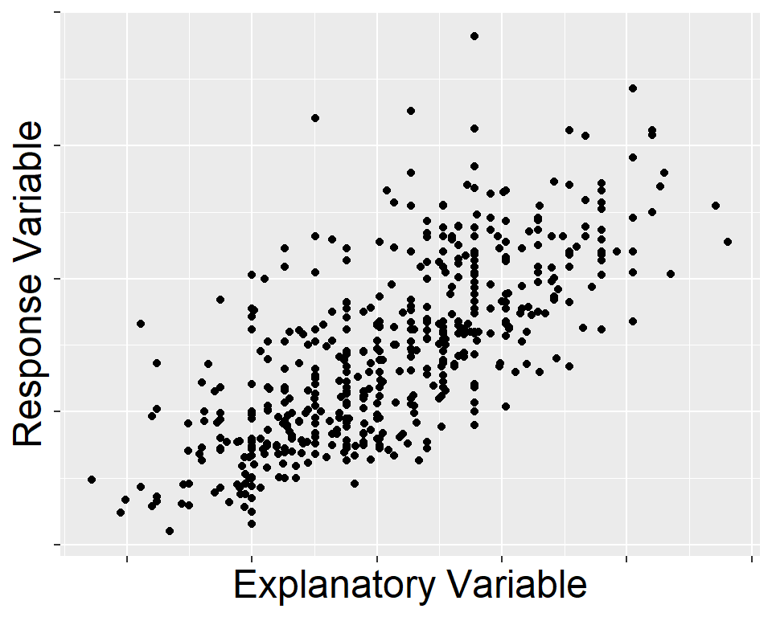

$\hat{y} = \hat{\beta}_0 + \hat{\beta}_1 \cdot x$

$\epsilon_i \sim N(0, \sigma^2)$

Fitting a Linear Regression

```r
lm(score ~ age, data = evals)
```

```
Call:
lm(formula = score ~ age, data = evals)

Coefficients:
(Intercept)          age
   4.461932    -0.005938
```

Using the `|>`

```r
evals |>
  lm(score ~ age, data = .x)
```

```
Error in is.data.frame(data): object '.x' not found
```

**What happened???**

Placeholder

Piping is an infix operator (e.g., `2 + 2`) that pipes the LHS of the pipe into the **first** argument of the function on RHS of the pipe

```r
evals %>%
  lm(score ~ age,
     data = .)
```

With `%>%`, if the LHS **should not** be used in the **first** argument, a `.` can be used to reference where the LHS should go.

```r
evals |>
  lm(score ~ age,
     data = _)
```

`|>` **does not** have a placeholder. However, as of R 4.2, `|>` can use `_` as a placeholder but only with **named** arguments.

[Interesting blog about differences by Isabella Velásquez](https://towardsdatascience.com/understanding-the-native-r-pipe-98dea6d8b61b)

Accessing Residuals & Fitted Values

*Objects in `evals_lm`*

`$fitted.values` `$residuals`

*Functions to extract elements from `evals_lm`*

- `resid()`
- `fitted()`

*Function to make a tibble of elements from `evals_lm`*

`broom::augment()`

An Example

```r
evals_lm$residuals |>
  head(4)
```

```
         1          2          3          4
 0.4518438 -0.1481562 -0.3481562  0.5518438
```

```r
resid(evals_lm) |>
  head(4)
```

```
         1          2          3          4
 0.4518438 -0.1481562 -0.3481562  0.5518438
```

```r
broom::augment(evals_lm)
```

```
# A tibble: 463 × 8
   score   age .fitted  .resid    .hat .sigma   .cooksd .std.resid
   <dbl> <int>   <dbl>   <dbl>   <dbl>  <dbl>     <dbl>      <dbl>
 1   4.7    36    4.25  0.452  0.00560  0.542 0.00197        0.837
 2   4.1    36    4.25 -0.148  0.00560  0.542 0.000212      -0.274
 3   3.9    36    4.25 -0.348  0.00560  0.542 0.00117       -0.645
 4   4.8    36    4.25  0.552  0.00560  0.541 0.00294        1.02
 5   4.6    59    4.11  0.488  0.00471  0.541 0.00193        0.904
 6   4.3    59    4.11  0.188  0.00471  0.542 0.000288       0.349
 7   2.8    59    4.11 -1.31   0.00471  0.538 0.0139        -2.43
 8   4.1    51    4.16 -0.0591 0.00232  0.542 0.0000139     -0.109
 9   3.4    51    4.16 -0.759  0.00232  0.541 0.00229       -1.40
10   4.5    40    4.22  0.276  0.00374  0.542 0.000488       0.510
# … with 453 more rows
```

Plotting Residuals

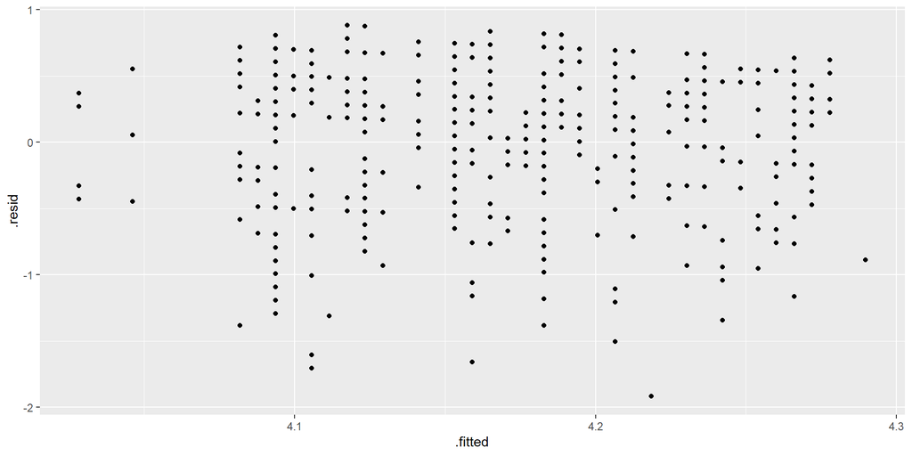

```r
evals_lm |>
  broom::augment() |>
  ggplot(mapping = aes(y = .resid, x = .fitted)) +
  geom_point()
```

Simulating Data

Functions in R

- `r` stands for for **random sampling**: generate a random value from a specific distribution
- `p` for **probability** (CDF): i.e. compute the probability of observing a value **less than** `x` (cumulative)
- `q` stands for **quantile**: given a probability `p`, compute the x-value such that $P(X < x) = p$
- `d` stands for **density** (PDF): compute the height of distribution curve (absolute)

Distributions in R

- Uniform – `unif`
- Normal – `norm`
- t – `t`
- Chi-Squared – `chisq`
- Binomial – `binom`